# Public Transit Optimization in Zurich

Josiah Chase

[Project Website](https://josiahchase.github.io)

```python
#mounting google drive
from google.colab import drive
drive.mount('/content/drive')

import pandas as pd
import numpy as np
import matplotlib.pyplot as plt
```

# Project Plan

The goal of this project is to investigate the efficiency of the public transit system in Zurich, Switzerland, and possible optimization strategies. How is it performing today? Are there possible areas for improvement? Zurich has one of the best public transit systems in the world, making it a good case study for other cities to use as a model for improvements. By looking at vehicle usage, route selection, and more we can quantify the performance of the Zurich public transit system. I hypothesize that there will be a relationship between high traffic stations and where delays are common. I also predict that busses will cause more delays than other vehicle types. I am also interested to find any unintuitive delay sources, perhaps at small stops, or those outside the city center.

# Extraction, Transform, and Load (ETL)

## Project Dataset

The Zurich City Government has an open database, [Open Data Zurich](https://data.stadt-zuerich.ch/). This project will use 2 weeks of passenger data from January 2-15, 2022. The data has been translated from the original German, and reposted on [Kaggle](https://www.kaggle.com/datasets/hanselliott/a-week-of-zurich-transit?resource=download). The original data was collected from tap in/out data from onboard payment stations on public transit vehicles, mainly trams and busses.

In the future, I'd like to scrape data from additional/more recent weeks to improve the analysis accuracy, as well as incoporate more exact timing data to calculate delays and performance more accurtely.

```python
#This code reads in the .csv files, and concatenates them into one dataframe.
df = pd.read_csv("/content/drive/MyDrive/IntroToDataSci/FinalProject/zurich_transit_20220102.csv")
df2 = pd.read_csv("/content/drive/MyDrive/IntroToDataSci/FinalProject/zurich_transit_20220109.csv")
zurich_2022 = pd.concat([df, df2], ignore_index=True)
zurich_2022
```

|  | unit_id | line | vehicle_id | course_id | transit_type | circulation_num | route_id | route_desig | route_type | from_stopnum | ... | from_sch_dep | from_act_dep | after_sch_arr | after_act_arr | after_sch_dep | after_act_dep | from_latitude | from_longitude | after_latitude | after_longitude |
| --- | --- | --- | --- | --- | --- | --- | --- | --- | --- | --- | --- | --- | --- | --- | --- | --- | --- | --- | --- | --- | --- |
| 0 | 1 | 2 | 3040 | 15 | T | 262402 | 158338 | BTIE - SGEI | 1 | 48 | ... | 44208 | 44214 | 44280 | 44296 | 44292 | 44310 | 47.378406 | 8.510109 | 47.381336 | 8.503520 |
| 1 | 2 | 2 | 3002 | 3 | T | 266003 | 158338 | BTIE - SGEI | 1 | 48 | ... | 33858 | 33861 | 33930 | 33962 | 33942 | 33972 | 47.378406 | 8.510109 | 47.381336 | 8.503520 |
| 2 | 3 | 2 | 3032 | 3 | T | 266003 | 158338 | BTIE - SGEI | 1 | 48 | ... | 85236 | 85187 | 85308 | 85266 | 85320 | 85284 | 47.378406 | 8.510109 | 47.381336 | 8.503520 |
| 3 | 4 | 2 | 3059 | 3 | T | 263968 | 158338 | BTIE - SGEI | 1 | 48 | ... | 70686 | 70655 | 70758 | 70724 | 70770 | 70734 | 47.378406 | 8.510109 | 47.381336 | 8.503520 |
| 4 | 5 | 2 | 2070 | 10 | T | 264746 | 158338 | BTIE - SGEI | 1 | 48 | ... | 72108 | 72123 | 72180 | 72195 | 72192 | 72204 | 47.378406 | 8.510109 | 47.381336 | 8.503520 |
| ... | ... | ... | ... | ... | ... | ... | ... | ... | ... | ... | ... | ... | ... | ... | ... | ... | ... | ... | ... | ... | ... |
| 2836093 | 1408584 | 919 | 11668 | 1 | BP | 264057 | 166511 | GAAZ - BKUE | 2 | 6044 | ... | 22620 | 22836 | 23520 | 23393 | 23520 | 23623 | 47.344406 | 8.572938 | 47.319129 | 8.580245 |
| 2836094 | 1408585 | 919 | 11663 | 4 | BP | 263025 | 166511 | GAAZ - BKUE | 2 | 6044 | ... | 57780 | 57822 | 58680 | 58401 | 58680 | 58751 | 47.344406 | 8.572938 | 47.319129 | 8.580245 |
| 2836095 | 1408586 | 919 | 11666 | 4 | BP | 263025 | 166511 | GAAZ - BKUE | 2 | 6044 | ... | 57780 | 57738 | 58680 | 58376 | 58680 | 58745 | 47.344406 | 8.572938 | 47.319129 | 8.580245 |
| 2836096 | 1408587 | 919 | 11666 | 4 | BP | 263025 | 166511 | GAAZ - BKUE | 2 | 6044 | ... | 57780 | 57894 | 58680 | 58404 | 58680 | 58763 | 47.344406 | 8.572938 | 47.319129 | 8.580245 |
| 2836097 | 1408588 | 919 | 11652 | 3 | BP | 262825 | 166519 | GAAZ - WALT ab Steig ri BKUE | 2 | 6044 | ... | 21360 | 21550 | 22140 | 22172 | 22140 | 22245 | 47.344406 | 8.572938 | 47.336093 | 8.617990 |

2836098 rows × 54 columns

```python
#Datatypes for each variable in the above dataframe.
zurich_2022.dtypes
```

|  | 0 |
| --- | --- |
| unit_id | int64 |
| line | int64 |
| vehicle_id | int64 |
| course_id | int64 |
| transit_type | object |
| circulation_num | int64 |
| route_id | int64 |
| route_desig | object |
| route_type | int64 |
| from_stopnum | int64 |
| from_stopshort | object |
| from_stopfull | object |
| after_stopnum | int64 |
| after_stopshort | object |
| after_stopfull | object |
| from_breakpoint | int64 |
| after_breakpoint | int64 |
| operating_date | object |
| from_date | object |
| after_date | object |
| direction | int64 |
| from_stop_seq | int64 |
| after_stop_seq | int64 |
| pax_per_yr | float64 |
| pax_per_day | float64 |
| pax_per_workday | float64 |
| pax_per_sa | float64 |
| pax_per_so | float64 |
| exit_per_yr | float64 |
| exit_per_day | float64 |
| exit_per_workday | float64 |
| exit_per_sa | float64 |
| exit_per_so | float64 |
| occ_per_yr | float64 |
| occ_per_day | float64 |
| occ_per_workday | float64 |
| occ_per_sa | float64 |
| occ_per_so | float64 |
| distance | float64 |
| seats | float64 |
| cap_4m2 | float64 |
| measurements | float64 |
| from_sch_arr | int64 |
| from_act_arr | int64 |
| from_sch_dep | int64 |
| from_act_dep | int64 |
| after_sch_arr | int64 |
| after_act_arr | int64 |
| after_sch_dep | int64 |
| after_act_dep | int64 |
| from_latitude | float64 |
| from_longitude | float64 |
| after_latitude | float64 |
| after_longitude | float64 |

**dtype:** object

# Exploratory Data Analysis

## Vehicle Type Frequency

The first seciton looks at the total number of trips on each type of transit vehicle within the system. B refers to busses (engine powered). BG, BL, BP, and BZ all refer to specific bus types. T refers to trams, TR to Trolleybusses, which are powered by overhead wires. Analyzing the usage of differnent transit types can let us identify which vehicle types cause the most issues, and therefore what can be improved.

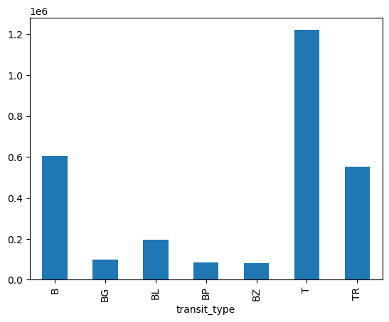

```python
#This calculates the total ridership over the two weeks for each of the transit vehicle types listed in the data.
zurich_2022.groupby("transit_type")["transit_type"].value_counts().plot.bar()
```

## Departure Station Usage

Identifying which stations are the most crowded allows us to pinpoint which areas of the network are causing the most stress, and therefore where resources need to be diverted. That could be in the form of timetable changes, or in infrastructure building.

```python
#Cound the number of total trips while grouped by stop name.
zurich_2022.groupby("from_stopfull")["from_stopfull"].count().sort_values(ascending=False)
```

| from_stopfull | from_stopfull |
| --- | --- |
| Zürich, Bellevue | 26928 |
| Zürich, Central | 26624 |
| Zürich, Paradeplatz | 25216 |
| Zürich, Escher-Wyss-Platz | 21656 |
| Zürich, Sternen Oerlikon | 21217 |
| ... | ... |
| Kilchberg ZH, Breitloo | 162 |
| Kilchberg ZH, Schlimbergstr. | 162 |
| Bergdietikon, Garage 2 LIBU | 152 |
| Schlieren, Meuchwis | 130 |
| Wädenswil, Garage Rütihof | 9 |

670 rows × 1 columns

**dtype:** int64

## Traffic by Day

Identifying which dates and days of the week allow us to optimize staff and equipment schedules to prevent delays, while also allowing proper equipment maintinene and proper employee rest, which will also improve performance on its own.

```python
#Count number of trips on each operating date in the table, grouped by date.
zurich_2022.groupby("operating_date")["operating_date"].count()
```

| operating_date | operating_date |
| --- | --- |
| 02.01.22 | 144440 |
| 03.01.22 | 217580 |
| 04.01.22 | 218763 |
| 05.01.22 | 219444 |
| 06.01.22 | 219035 |
| 07.01.22 | 220789 |
| 08.01.22 | 187459 |
| 09.01.22 | 142134 |
| 10.01.22 | 214350 |
| 11.01.22 | 215627 |
| 12.01.22 | 215067 |
| 13.01.22 | 216489 |
| 14.01.22 | 218417 |
| 15.01.22 | 186504 |

**dtype:** int64

## Lines at each Station

By observing which stations play host to transit lines, we can predict where there will be the most passenger transfers. This stops will be most important to optimze schedules for, as passenger transfers increase traffic and delays, and when those delays happen, they ripple through the network as passengers continue on their delayed journey.

```python
#Show unique line values grouped by stop name.
zurich_2022.groupby(["from_stopfull"])["line"].unique()
```

| from_stopfull | line |
| --- | --- |
| Adliswil, Ahornweg | [162, 185] |
| Adliswil, Badstrasse | [185] |
| Adliswil, Bahnhof | [184, 185] |
| Adliswil, Dietlimoos | [185] |
| Adliswil, Grundstrasse | [185] |
| ... | ... |
| Zürich, Zwielplatz | [13, 80] |
| Zürich, Zwinglihaus | [32, 66, 72] |
| Zürich, Zypressenstrasse | [2, 3, 4] |
| Zürich, Zürichbergstrasse | [5, 6] |
| Zürich,Kalkbreite/Bhf.Wiedikon | [2, 3, 4, 14, 32] |

670 rows × 1 columns

**dtype:** object

```python
#Convert to HTML
!jupyter nbconvert --to html /content/drive/MyDrive/IntroToDataSci/FinalProject/Chase-ZurichTransitOptimization.ipynb
```

[output not shown]